# Descriptive Analysis of Fracturing Data for Montney Wells

Dr. Yingkun Fu

2021/1/11

## R Markdown

Here I present the statistic analysis of fracturing data for wells completed in the Montney wells. The fracturing, well information, and production data were deposited in .csv files (retrieved from www.bcogc.ca on December of 2020). These wells are identified with a unique well ID named UWI.

In this section, I mainly analyzed the fracturing information of _wells. These fracturing information include number of fracturing stages, completion types, fracturing treatment pressures (breakdown pressure, maximum treating pressure, average treating pressure, ISIP), frac-gradient, total fracturing volume (TIV), total volume of energizers (N2 and/or CO2), proppant type, and Acid volume.

First, I load the packages required for descriptive analysis and data data manipulation.

## Question-1: How many Montney wells in total?

### Frequencies

#### selectedf_well_index$Form

**Type:** Character

|  | Freq | % |
| --- | --- | --- |
| **5000** | 2862 | 84.375 |
| **4997** | 292 | 8.608 |
| **4900** | 36 | 1.061 |
| **8200** | 36 | 1.061 |
| **2800** | 28 | 0.825 |
| **8295** | 22 | 0.649 |
| **6200** | 14 | 0.413 |
| **8550** | 14 | 0.413 |
| **4800** | 13 | 0.383 |
| **2600** | 12 | 0.354 |
| **2010** | 11 | 0.324 |
| **4805** | 6 | 0.177 |
| **2885** | 5 | 0.147 |
| **7730** | 5 | 0.147 |
| **2700** | 4 | 0.118 |
| **4100** | 4 | 0.118 |
| **4520** | 3 | 0.088 |
| **1730** | 2 | 0.059 |
| **2550** | 2 | 0.059 |
| **2805** | 2 | 0.059 |
| **4500** | 2 | 0.059 |
| **8290** | 2 | 0.059 |
| **1500** | 1 | 0.029 |
| **1720** | 1 | 0.029 |
| **2000** | 1 | 0.029 |
| **2500** | 1 | 0.029 |
| **2505** | 1 | 0.029 |
| **2850** | 1 | 0.029 |
| **3200** | 1 | 0.029 |
| **4510** | 1 | 0.029 |
| **4530** | 1 | 0.029 |
| **4575** | 1 | 0.029 |
| **4580** | 1 | 0.029 |
| **6250** | 1 | 0.029 |
| **7700** | 1 | 0.029 |
| **8125** | 1 | 0.029 |
| **8285** | 1 | 0.029 |

## Question-2: What are the fluid types of thes Montney wells?

I further examined the fluid types of these wells. As shown the table below, there are 2703 and 138 gas and oil wells (94% and 5%), respectively. To date, about 96% wells (n=2750) are actively producing, while about 3% of wells (n=92) has been suspended.

### Frequencies

#### Mont_wells$Mode

**Type:** Character

|  | Freq | % |
| --- | --- | --- |
| **ACT** | 2750 | 96.087 |
| **SUSP** | 92 | 3.215 |
| **COMP** | 9 | 0.314 |
| **ABNZ** | 7 | 0.245 |
| **GAST** | 3 | 0.105 |
| **ABAN** | 1 | 0.035 |

### Frequencies

#### Mont_wells$Fluid

**Type:** Character

|  | Freq | % |
| --- | --- | --- |
| **GAS** | 2703 | 94.444 |
| **OIL** | 138 | 4.822 |
| **UND** | 18 | 0.629 |
| **MGAS** | 2 | 0.070 |
| **WATR** | 1 | 0.035 |

## Question-3: What are the breakdown pressure, ISIP, average fracturing pressure, and maximum treatment pressure, frac-gradient, and average rate for these fractured Montney wells? Are these any difference between different completion strategies?

### Fracturing Pressure and Rates

The Montney wells mainly fractured with two strategies: single-cluster (SGNL) and open-hole completion, which account for about 50% of completion strategies each. Although they are fractured with a pretty close average pumping rate, interestingly, comparatively analysis show a higher ISIP, maximum treatment pressure, breakdown pressure, average treatment pressure in the single-shot completed wells (SGNL) than those wells with open-hole completion strategy. The difference between the pressure can be several Mpa. How to explain the difference in fracturing parameters between these two srategies? One may expect a pressure loss is required for fracturing fluid flowing from werllbore into perforation holes, and that flow from tubing to casing. The pressure loss can thus be several Megapasica.

Sumamry of Fracturing-pressure Parameters

|  | DUAL (N=3) | OHB (N=36477) | SNGL (N=35907) | Total (N=72387) | p value |
| --- | --- | --- | --- | --- | --- |
| **BREAK.DOWN.PRESSURE..MPa.** |  |  |  |  | < 0.001 |
| N-Miss | 0 | 2916 | 442 | 3358 |  |
| Mean (SD) | 25.900 (24.225) | 39.573 (11.215) | 48.485 (11.371) | 44.151 (12.143) |  |
| Range | 0.000 - 48.000 | 0.000 - 421.900 | 0.000 - 591.900 | 0.000 - 591.900 |  |
| **INST.SHUT.IN.PRESSURE..MPa.** |  |  |  |  | < 0.001 |
| N-Miss | 2 | 25152 | 1956 | 27110 |  |
| Mean (SD) | 0.000 (NA) | 17.670 (14.739) | 26.567 (8.573) | 24.341 (11.149) |  |
| Range | 0.000 - 0.000 | 0.000 - 72.000 | 0.000 - 329.000 | 0.000 - 329.000 |  |
| **MAX.TREATING.PRESSURE..MPa.** |  |  |  |  | < 0.001 |
| N-Miss | 0 | 111 | 75 | 186 |  |
| Mean (SD) | 45.363 (11.750) | 54.474 (10.690) | 60.016 (11.542) | 57.224 (11.461) |  |
| Range | 33.600 - 57.100 | 0.000 - 630.500 | 0.000 - 732.300 | 0.000 - 732.300 |  |
| **AVG.TREATING.PRESSURE..MPa.** |  |  |  |  | < 0.001 |
| N-Miss | 0 | 219 | 160 | 379 |  |
| Mean (SD) | 39.707 (14.233) | 50.054 (9.027) | 53.660 (8.531) | 51.844 (8.968) |  |
| Range | 29.700 - 56.000 | 0.000 - 82.100 | 0.000 - 80.870 | 0.000 - 82.100 |  |
| **AVG.RATE..m3.min.** |  |  |  |  | 0.580 |
| N-Miss | 0 | 3675 | 327 | 4002 |  |
| Mean (SD) | 7.433 (4.446) | 8.674 (2.523) | 8.690 (3.170) | 8.683 (2.878) |  |
| Range | 2.300 - 10.000 | 0.000 - 98.500 | 0.000 - 80.900 | 0.000 - 98.500 |  |
| **FRAC.GRADIENT..KPa.m.** |  |  |  |  | < 0.001 |
| N-Miss | 2 | 23031 | 3324 | 26357 |  |
| Mean (SD) | 0.000 (NA) | 20.055 (7.112) | 22.158 (6.522) | 21.543 (6.768) |  |
| Range | 0.000 - 0.000 | 0.000 - 50.390 | 0.000 - 907.240 | 0.000 - 907.240 |  |

### Fracturing Stages and Fluid Volume

As listed in the table below, the Montney wells were fractured with an average number of 25 stages (the mode value is 9 stages). The maximum number os stages is 125. The average injected volume of fracturing water is about 14154 m3. The nitrogen is injected at high volume at the pressure >50 MPa, and thus expected to be under liquid condition. The average total injected volume of N2 at surface condition is 320588 standard m3.

The table below summarizes the statistic results of fracturing-fluid parameters. The results show a total number of 67333 stages of 2602 wells were fractured only with water, while the other 5054 stages were fractured with energizers including Nitrogen and Carbon Dioxide. Among these stages, 27 out of 5054 stages were fractured with pure CO2 (n=4 wells), 4942 out of 5054 stages with N2 (n=360 wells), and the remaining 84 stages were fractured with the combination of CO2 and N2 (6 wells).

Among these stages fractured with pure CO2, the ratio of fracturing water to CO2 injected volume is about 1:1 for each stage. The mean injected volume of CO2-fracture wells is about 152 m3 (SD=123) per stage.The mean total injected volume for hydraulic fractured wells is about 552 (SD=381) m3 per stage.

Sumamry of Fracturing-fluid Parameters

|  | (N=1) | CO2 (N=27) | CO2/N2 (N=84) | N2 (N=4942) | NONE (N=67333) | Total (N=72387) | p value |
| --- | --- | --- | --- | --- | --- | --- | --- |
| **ENERGIZER.TYPE** |  |  |  |  |  |  | < 0.001 |
|  | 1 (100.0%) | 0 (0.0%) | 0 (0.0%) | 0 (0.0%) | 0 (0.0%) | 1 (0.0%) |  |
| CO2 | 0 (0.0%) | 27 (100.0%) | 0 (0.0%) | 0 (0.0%) | 0 (0.0%) | 27 (0.0%) |  |
| CO2/N2 | 0 (0.0%) | 0 (0.0%) | 84 (100.0%) | 0 (0.0%) | 0 (0.0%) | 84 (0.1%) |  |
| N2 | 0 (0.0%) | 0 (0.0%) | 0 (0.0%) | 4942 (100.0%) | 0 (0.0%) | 4942 (6.8%) |  |
| none | 0 (0.0%) | 0 (0.0%) | 0 (0.0%) | 0 (0.0%) | 1053 (1.6%) | 1053 (1.5%) |  |
| None | 0 (0.0%) | 0 (0.0%) | 0 (0.0%) | 0 (0.0%) | 43754 (65.0%) | 43754 (60.4%) |  |
| NONE | 0 (0.0%) | 0 (0.0%) | 0 (0.0%) | 0 (0.0%) | 22526 (33.5%) | 22526 (31.1%) |  |
| **TOTAL.FLUID.PUMPED..m3.** |  |  |  |  |  |  | < 0.001 |
| N-Miss | 0 | 0 | 0 | 1 | 61 | 62 |  |
| Mean (SD) | 7.000 (NA) | 271.011 (91.058) | 193.415 (124.680) | 718.258 (544.787) | 552.034 (381.277) | 562.861 (396.814) |  |
| Range | 7.000 - 7.000 | 71.600 - 406.900 | 28.600 - 509.000 | 0.000 - 2788.500 | 0.000 - 8742.000 | 0.000 - 8742.000 |  |
| **TOTAL.CO2.PUMPED..m3.** |  |  |  |  |  |  |  |
| N-Miss | 1 | 14 | 30 | 2995 | 50229 | 53269 |  |
| Mean (SD) | NA | 151.815 (123.048) | 138.335 (58.024) | 0.111 (1.624) | 5.447 (59.530) | 5.378 (57.069) |  |
| Range | NA | 85.000 - 458.600 | 43.900 - 365.600 | 0.000 - 25.800 | 0.000 - 974.900 | 0.000 - 974.900 |  |
| **TOTAL.N2.PUMPED..scm.** |  |  |  |  |  |  |  |
| N-Miss | 1 | 25 | 1 | 10 | 50184 | 50221 |  |
| Mean (SD) | NA | 0.000 (0.000) | 19334.095 (15336.997) | 21776.853 (25370.196) | 8.356 (395.206) | 4924.274 (15061.695) |  |
| Range | NA | 0.000 - 0.000 | 20.000 - 60361.000 | 0.000 - 287471.000 | 0.000 - 34033.000 | 0.000 - 287471.000 |  |

Sumamry of Fracturing Parameters

|  | (N=1) | CO2 (N=4) | CO2/N2 (N=6) | N2 (N=360) | NONE (N=2602) | Total (N=2973) | p value |
| --- | --- | --- | --- | --- | --- | --- | --- |
| **n_stages** |  |  |  |  |  |  | < 0.001 |
| Mean (SD) | 23.000 (NA) | 7.250 (6.850) | 19.333 (7.312) | 17.244 (10.397) | 26.207 (12.416) | 25.081 (12.536) |  |
| Range | 23.000 - 23.000 | 1.000 - 15.000 | 12.000 - 29.000 | 1.000 - 54.000 | 1.000 - 125.000 | 1.000 - 125.000 |  |
| **total_co2_v** |  |  |  |  |  |  |  |
| N-Miss | 1 | 2 | 2 | 233 | 1934 | 2172 |  |
| Mean (SD) | NA | 499.350 (495.187) | 1867.525 (348.389) | 18.787 (193.404) | 147.485 (1408.332) | 136.548 (1295.347) |  |
| Range | NA | 149.200 - 849.500 | 1418.900 - 2170.600 | 0.000 - 2170.600 | 0.000 - 20625.800 | 0.000 - 20625.800 |  |
| **total_N2_v** |  |  |  |  |  |  |  |
| N-Miss | 1 | 3 | 1 | 40 | 1929 | 1974 |  |
| Mean (SD) | NA | 0.000 (NA) | 320986.780 (206409.315) | 320588.126 (342381.887) | 25553.355 (157676.130) | 121512.054 (271131.325) |  |
| Range | NA | 0.000 - 0.000 | 121613.000 - 594280.000 | 0.000 - 2131245.600 | 0.000 - 2131245.600 | 0.000 - 2131245.600 |  |
| **TIV** |  |  |  |  |  |  | < 0.001 |
| N-Miss | 0 | 0 | 0 | 2 | 39 | 41 |  |
| Mean (SD) | 6514.800 (NA) | 1832.825 (2219.355) | 4093.917 (3750.654) | 11746.168 (5006.422) | 14535.523 (9015.848) | 14153.507 (8683.526) |  |
| Range | 6514.800 - 6514.800 | 71.600 - 4940.000 | 1021.600 - 9139.500 | 89.500 - 28268.000 | 111.000 - 100959.900 | 71.600 - 100959.900 |  |

## Data Visualization –>

Here, I visualize the distribution of fracturing parameters investigated on Montney wells. I also explored the inter-dependency between the parameters through correlation analysis.

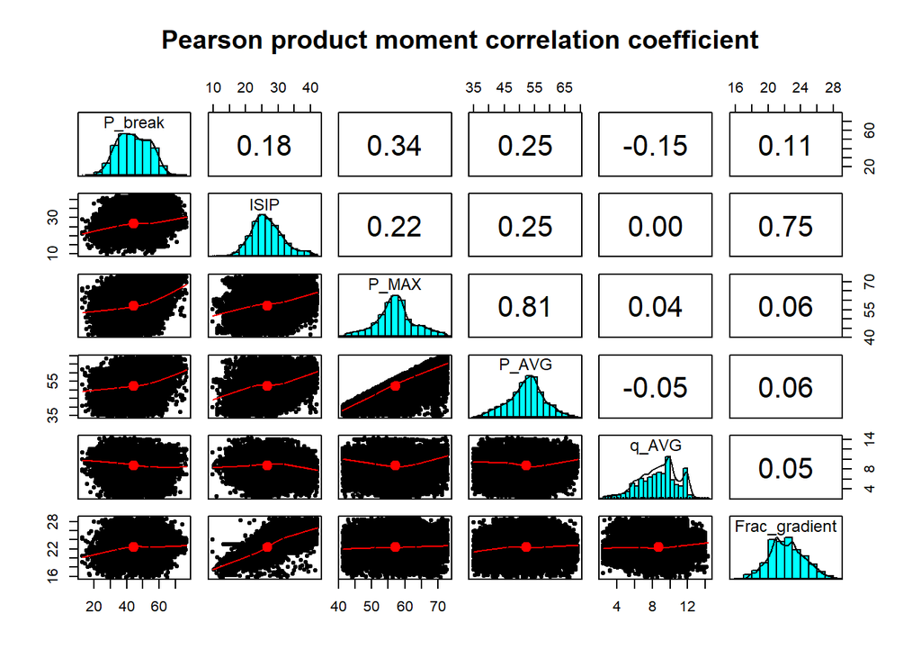